# Systematic Trading Strategies with ML — Meta-Model Submission

**Imperial College London × Alken Asset Management.** A *meta-model* that takes the provided primary trading signal `s ∈ {-1, 0, +1}` for 11 futures and predicts, for each non-zero signal, the **probability that following the trade is profitable** under a triple-barrier exit.

This notebook is the full deliverable. **Part I (this file so far)** establishes the *foundations* the model consumes, in four steps:

1. **Exploratory data analysis** — the raw price panel and the character of the primary signal.
2. **External macro dataset** — the Bloomberg cross-asset series we added (feature family **F11**).
3. **HMM regime features** — the learned volatility-regime states (families **F3** and **F17**).
4. **Feature engineering** — the full catalogue of feature families (**F1–F17**) and how they are built.

The later parts — triple-barrier *labelling*, *meta-model fitting*, and *position-sizing / weight extraction* — follow these foundations.

> **Scope / non-duplication.** This notebook owns the **raw-data and signal EDA** plus the **feature foundations**. The downstream *modelling* diagnostics (feature-redundancy clustering, per-family missingness, cluster-level importance) live in the model-development notebook `metamodel.ipynb` (§1/§7) and are not repeated here.

## Section 0 — Setup & data load

```python
%matplotlib inline
import json, re, collections, warnings
from pathlib import Path
import numpy as np, pandas as pd
import matplotlib.pyplot as plt
warnings.filterwarnings("ignore")
np.random.seed(42); SEED = 42
plt.rcParams["figure.dpi"] = 100
pd.set_option("display.width", 160); pd.set_option("display.max_columns", 40)

from stml.io import _find_repo_root, load_clean_data, load_returns_panel
from stml import na_checks as nc
from stml.model.dataset import load_matrix, close_panel, events_frame, asset_class_map

ROOT = _find_repo_root(Path.cwd().resolve())
DATA, RESULTS, REPORTS = ROOT / "data", ROOT / "results", ROOT / "reports"

ohlcv, signals = load_clean_data()      # ohlcv: long OHLCV ; signals: wide (date + 11 instrument cols)
matrix  = load_matrix()                 # the engineered feature matrix (nonzero-signal trade-days)
close_w = close_panel()                 # wide close prices, date-indexed, instrument columns
ret_w   = load_returns_panel()          # wide daily LOG returns, full price history
sig_w   = signals.set_index("date")     # wide signals, date-indexed
INSTR   = list(nc.INSTRUMENTS)          # canonical 11-instrument order
CLASS   = asset_class_map()             # {instrument -> 'EQ' / 'EN' / 'ME'}
prov    = json.load(open(RESULTS / "feature_matrix_provenance.json"))

TICKER_NAMES = {
    "cl1s": "Crude Oil (CL)",   "es1s": "S&P 500 e-mini (ES)", "fesx1s": "Euro Stoxx 50 (FESX)",
    "gc1s": "Gold (GC)",        "hg1s": "Copper (HG)",         "ho1s": "Heating Oil (HO)",
    "ng1s": "Natural Gas (NG)", "nq1s": "Nasdaq 100 (NQ)",     "pl1s": "Platinum (PL)",
    "rb1s": "RBOB Gasoline (RB)", "si1s": "Silver (SI)",
}

assert prov["fe_train_end_date"] == "2021-07-01"
print(f"matrix: {matrix.shape[0]:,} nonzero-signal rows x {matrix.shape[1]} cols "
      f"({prov['n_feature_cols']} features + 4 metadata)")
print(f"instruments: {len(INSTR)} | FE-train boundary <= {prov['fe_train_end_date']} | seed {prov['seed']}")
print(f"signal window: {sig_w.index.min().date()} -> {sig_w.index.max().date()}")
```

```
matrix: 4,984 nonzero-signal rows x 179 cols (175 features + 4 metadata)
instruments: 11 | FE-train boundary <= 2021-07-01 | seed 0
signal window: 2020-01-03 -> 2022-06-30
```

```python
# Capability probe — the HMM transition-matrix display (Section 3) needs a live fit, which requires
# `hmmlearn`. Everything else (incl. the already-materialised f3_*/f17_* columns) runs without it.
try:
    import hmmlearn  # noqa: F401
    CAP_HMM = True
except Exception:
    CAP_HMM = False
print("hmmlearn available:", CAP_HMM, "" if CAP_HMM else "(run `uv sync --group features-extra`)")
```

```
hmmlearn available: True
```

## Section 1 — Exploratory data analysis

### 1.1 — Coverage: a two-window dataset

The 11 instruments span three asset classes — **Equity** (`es1s`, `nq1s`, `fesx1s`), **Energy** (`cl1s`, `ho1s`, `rb1s`, `ng1s`) and **Metals** (`gc1s`, `si1s`, `hg1s`, `pl1s`). The commodity contracts carry ~30 years of price history; the equity indices start later. Critically, the **primary signal** only exists for **2020-01 → 2022-06**. The decades of price history exist *only* to warm up trailing features causally — all modelling happens inside the short signal window.

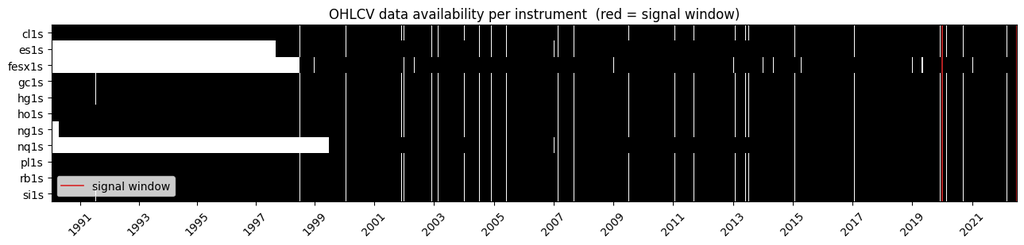

```
11 instruments: 8 commodities (~30y history), 3 equity indices; signal window 2020-01-03 -> 2022-06-30
```

```python
# Data-availability heatmap (one row per instrument; red lines mark the signal window).
avail = close_w.notna().astype(int).T          # instrument x date
fig, ax = plt.subplots(figsize=(13, 3.2))
ax.imshow(avail.values, aspect="auto", cmap="Greys", interpolation="nearest")
ax.set_yticks(range(len(avail.index))); ax.set_yticklabels(avail.index)
yrs = pd.to_datetime(avail.columns).year
yr_changes = np.where(np.diff(yrs) != 0)[0] + 1
step = max(1, len(yr_changes) // 12)
ax.set_xticks(yr_changes[::step]); ax.set_xticklabels([str(yrs[i]) for i in yr_changes[::step]], rotation=45)
s0 = avail.columns.get_indexer([signals.date.min()], method="nearest")[0]
s1 = avail.columns.get_indexer([signals.date.max()], method="nearest")[0]
ax.axvline(s0, color="C3", lw=1.2, label="signal window"); ax.axvline(s1, color="C3", lw=1.2)
ax.set_title("OHLCV data availability per instrument  (red = signal window)")
ax.legend(loc="lower left"); plt.tight_layout(); plt.show()

n_eq = sum(CLASS[i] == "EQ" for i in INSTR)
print(f"{len(INSTR)} instruments: {len(INSTR)-n_eq} commodities (~30y history), {n_eq} equity indices; "
      f"signal window {sig_w.index.min().date()} -> {sig_w.index.max().date()}")
```

### 1.2 — Return structure: stationary but heavy-tailed

```python
# Per-instrument return summary over the full price history (log returns).
ANN = np.sqrt(252)
ret_summary = pd.DataFrame({
    "name":          pd.Series(TICKER_NAMES),
    "mean_daily_bp": ret_w.mean() * 1e4,
    "ann_vol_%":     ret_w.std() * ANN * 100,
    "skew":          ret_w.skew(),
    "kurtosis":      ret_w.kurt(),          # excess kurtosis; >> 0 = fat tails
    "min_day_%":     ret_w.min() * 100,
    "max_day_%":     ret_w.max() * 100,
    "n_obs":         ret_w.count(),
}).reindex(INSTR).round(2)
display(ret_summary)
```

|  | name | mean_daily_bp | ann_vol_% | skew | kurtosis | min_day_% | max_day_% | n_obs |
| --- | --- | --- | --- | --- | --- | --- | --- | --- |
| cl1s | Crude Oil (CL) | 0.50 | 40.18 | -2.10 | 48.65 | -56.86 | 22.39 | 8170 |
| es1s | S&P 500 e-mini (ES) | 2.01 | 19.83 | -0.27 | 10.89 | -10.96 | 13.20 | 6295 |
| fesx1s | Euro Stoxx 50 (FESX) | 0.70 | 24.31 | -0.14 | 5.88 | -11.99 | 13.19 | 6107 |
| gc1s | Gold (GC) | 0.71 | 16.13 | -0.27 | 7.50 | -9.81 | 8.83 | 8169 |
| hg1s | Copper (HG) | 1.72 | 25.54 | -0.18 | 4.04 | -11.71 | 11.64 | 8170 |
| ho1s | Heating Oil (HO) | 1.91 | 35.09 | -0.98 | 17.64 | -39.09 | 13.99 | 8168 |
| ng1s | Natural Gas (NG) | -7.71 | 49.48 | -0.03 | 2.80 | -18.07 | 18.76 | 8103 |
| nq1s | Nasdaq 100 (NQ) | 2.27 | 27.50 | -0.06 | 7.03 | -11.48 | 15.44 | 5844 |
| pl1s | Platinum (PL) | 0.69 | 22.66 | -0.40 | 5.00 | -12.32 | 11.19 | 8168 |
| rb1s | RBOB Gasoline (RB) | 3.38 | 38.02 | -1.23 | 20.11 | -38.54 | 22.40 | 8169 |
| si1s | Silver (SI) | 0.28 | 29.03 | -0.76 | 7.54 | -19.49 | 12.47 | 8170 |

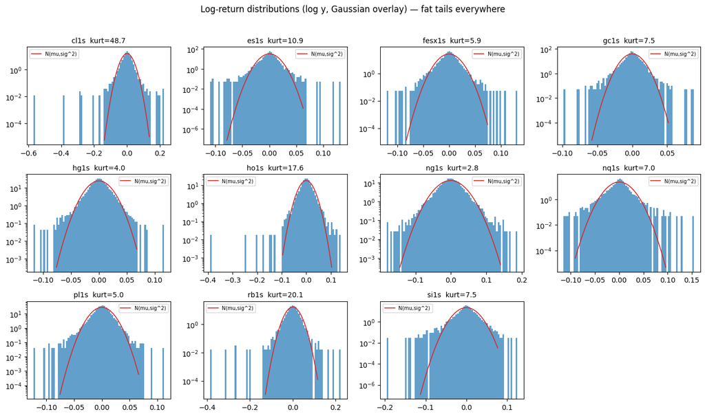

```python
# Log-return distributions with a Gaussian overlay (log y-axis exposes the tails).
fig, axes = plt.subplots(3, 4, figsize=(14, 8))
for ax, inst in zip(axes.flat, INSTR):
    r = ret_w[inst].dropna()
    ax.hist(r, bins=80, density=True, alpha=0.7, color="C0")
    xs = np.linspace(r.quantile(0.001), r.quantile(0.999), 200)
    ax.plot(xs, (1/(r.std()*np.sqrt(2*np.pi))) * np.exp(-0.5*((xs-r.mean())/r.std())**2),
            color="C3", lw=1.2, label="N(mu,sig^2)")
    ax.set_title(f"{inst}  kurt={r.kurt():.1f}", fontsize=10); ax.set_yscale("log")
    ax.legend(fontsize=7)
for ax in axes.flat[len(INSTR):]:
    ax.set_visible(False)
fig.suptitle("Log-return distributions (log y, Gaussian overlay) — fat tails everywhere", y=1.02)
plt.tight_layout(); plt.show()
```

### 1.3 — Cross-sectional structure: three blocks

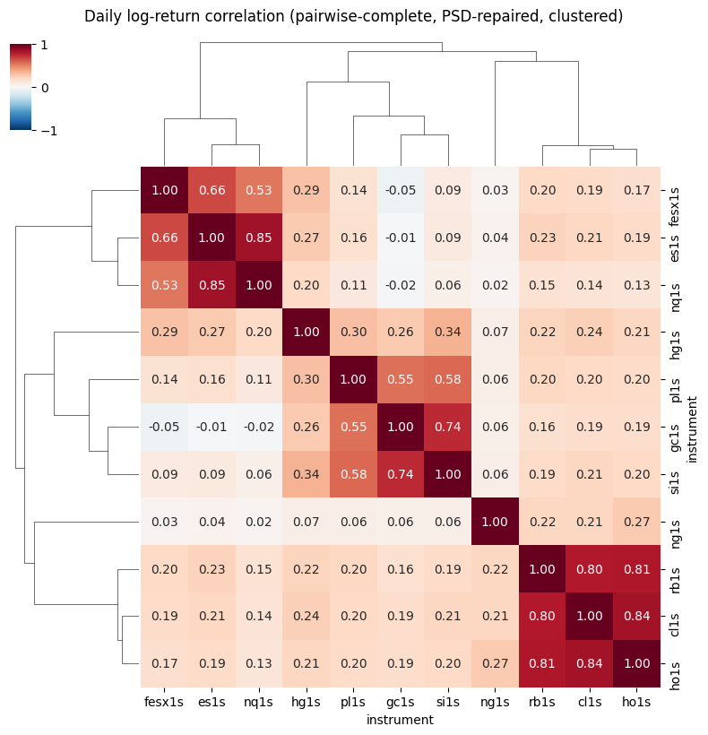

```python
import seaborn as sns
# corr_max_info: pairwise-complete (max data, not truncated to shortest history) + PSD-repaired.
corr = nc.corr_max_info(ret_w, min_periods=252)
g = sns.clustermap(corr, annot=True, fmt=".2f", cmap="RdBu_r", center=0, vmin=-1, vmax=1,
                   figsize=(8, 8), cbar_pos=(0.02, 0.85, 0.03, 0.12))
g.fig.suptitle("Daily log-return correlation (pairwise-complete, PSD-repaired, clustered)", y=1.02)
plt.show()
```

### 1.4 — The primary signal: imbalanced, persistent, near-independent

| instrument | p(s=-1) | p(s=0) | p(s=1) | lag1_autocorr | mean_run_len | nonzero_frac |
| --- | --- | --- | --- | --- | --- | --- |
| cl1s | 0.056 | 0.346 | 0.598 | 0.791 | 8.6 | 0.654 |
| es1s | 0.184 | 0.109 | 0.707 | 0.584 | 5.1 | 0.891 |
| fesx1s | 0.544 | 0.012 | 0.443 | 0.509 | 4.0 | 0.988 |
| gc1s | 0.050 | 0.740 | 0.211 | 0.619 | 2.9 | 0.260 |
| hg1s | 0.495 | 0.026 | 0.479 | 0.647 | 5.2 | 0.974 |
| ho1s | 0.016 | 0.902 | 0.082 | 0.534 | 2.2 | 0.098 |
| ng1s | 0.192 | 0.808 | 0.000 | 0.760 | 5.2 | 0.192 |
| nq1s | 0.313 | 0.064 | 0.623 | 0.556 | 4.4 | 0.936 |
| pl1s | 0.211 | 0.136 | 0.653 | 0.663 | 5.4 | 0.864 |
| rb1s | 0.405 | 0.026 | 0.569 | 0.769 | 7.8 | 0.974 |
| si1s | 0.422 | 0.104 | 0.474 | 0.600 | 4.0 | 0.896 |

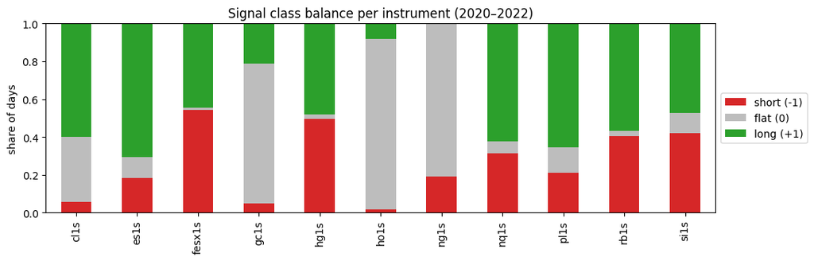

```python
# Class balance + persistence per instrument.
long_sig = signals.melt(id_vars="date", var_name="instrument", value_name="s")
bal = (long_sig.groupby("instrument")["s"].value_counts(normalize=True)
       .unstack(fill_value=0).round(3))
bal.columns = [f"p(s={int(c)})" for c in bal.columns]
rows = []
for inst in INSTR:
    s = sig_w[inst]
    runs = (s != s.shift()).cumsum()
    rl = s[s != 0].groupby(runs).size()
    rows.append({"instrument": inst, "lag1_autocorr": round(s.autocorr(1), 3),
                 "mean_run_len": round(rl.mean(), 1) if len(rl) else 0.0,
                 "nonzero_frac": round((s != 0).mean(), 3)})
persist = pd.DataFrame(rows).set_index("instrument")
display(bal.join(persist).reindex(INSTR))

# Stacked class-share bar.
shares = pd.DataFrame({
    "short (-1)": (sig_w == -1).mean(), "flat (0)": (sig_w == 0).mean(), "long (+1)": (sig_w == 1).mean(),
}).reindex(INSTR)
ax = shares.plot(kind="bar", stacked=True, figsize=(11, 3.6),
                 color=["#d62728", "#bdbdbd", "#2ca02c"])
ax.set_ylabel("share of days"); ax.set_ylim(0, 1)
ax.set_title("Signal class balance per instrument (2020–2022)")
ax.legend(loc="center left", bbox_to_anchor=(1.0, 0.5)); plt.tight_layout(); plt.show()
```

### 1.5 — Signal × forward returns: the signal predicts the *next* bar

The single most important EDA finding for labelling. Two complementary views agree:

- **Lead/lag** `corr(s_t, r_{t+k})` is strongest at **k = +1** — the signal *leads* the return.
- The **raw signed-return Sharpe by lag** (`g_i(L) = s_i · u_{t+L}`, from the labelling study) is *negative* at **lag 0** (contemporaneous) for most instruments, **strongest at lag 1**, and decays by lag 2 — a textbook **placebo-in-time** pattern.

```python
# (a) Per-instrument corr(s_t, r_{t+1}), mean pnl and hit rate.
rets_s = close_w.pct_change()
hit = []
for inst in INSTR:
    s = sig_w[inst].reindex(close_w.index); fwd = rets_s[inst].shift(-1)
    m = (s != 0) & fwd.notna(); pnl = (s * fwd)[m]
    hit.append({"instrument": inst, "corr_s_rfwd": round(float(s[m].corr(fwd[m])), 3),
                "mean_pnl_bp": round(float(pnl.mean()) * 1e4, 2),
                "hit_rate": round(float((pnl > 0).mean()), 3), "n": int(m.sum())})
display(pd.DataFrame(hit).set_index("instrument").reindex(INSTR))
print("corr(s_t, r_{t+1}) is mostly positive -> the signal predicts the NEXT bar (counter-trend flavour).")
```

| instrument | corr_s_rfwd | mean_pnl_bp | hit_rate | n |
| --- | --- | --- | --- | --- |
| cl1s | 0.078 | 65.98 | 0.032 | 7813 |
| es1s | 0.129 | 17.94 | 0.052 | 6134 |
| fesx1s | 0.052 | 8.12 | 0.056 | 6029 |
| gc1s | 0.178 | 28.68 | 0.014 | 7565 |
| hg1s | 0.115 | 17.59 | 0.042 | 8014 |
| ho1s | 0.009 | 43.54 | 0.006 | 7463 |
| ng1s | NaN | 68.76 | 0.009 | 7455 |
| nq1s | 0.130 | 24.22 | 0.055 | 5718 |
| pl1s | 0.068 | 14.70 | 0.037 | 7941 |
| rb1s | 0.072 | 29.55 | 0.041 | 8012 |
| si1s | 0.055 | 13.07 | 0.037 | 7964 |

```
corr(s_t, r_{t+1}) is mostly positive -> the signal predicts the NEXT bar (counter-trend flavour).
```

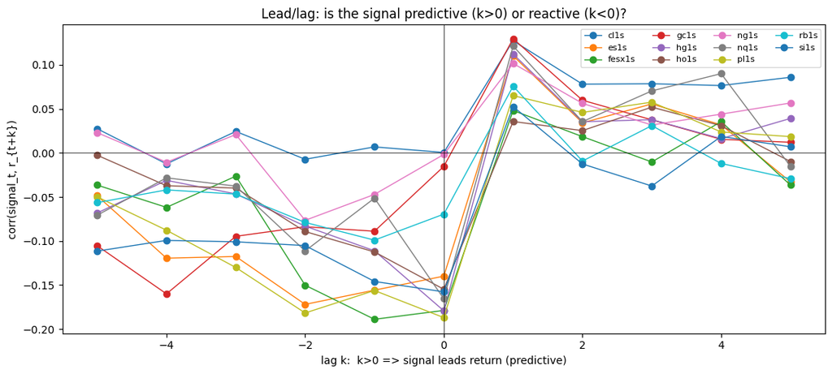

```python
# (b) Lead/lag: corr(signal_t, r_{t+k}) for k in [-5..5].  k>0 = signal leads return = predictive.
lags = range(-5, 6)
lead_lag = pd.DataFrame(index=lags, columns=INSTR, dtype=float)
for k in lags:
    aligned = ret_w.shift(-k).reindex(sig_w.index)
    for inst in INSTR:
        a = sig_w[inst].astype(float); b = aligned[inst]
        ok = a.notna() & b.notna()
        if ok.sum() > 30 and a[ok].std() > 0 and b[ok].std() > 0:
            lead_lag.loc[k, inst] = a[ok].corr(b[ok])
fig, ax = plt.subplots(figsize=(11, 5))
for inst in INSTR:
    ax.plot(lead_lag.index, lead_lag[inst], marker="o", lw=1.0, label=inst)
ax.axvline(0, color="k", lw=0.5); ax.axhline(0, color="k", lw=0.5)
ax.set_xlabel("lag k:  k>0 => signal leads return (predictive)")
ax.set_ylabel("corr(signal_t, r_{t+k})")
ax.set_title("Lead/lag: is the signal predictive (k>0) or reactive (k<0)?")
ax.legend(ncol=4, fontsize=8); plt.tight_layout(); plt.show()
```

```python
# (c) Raw signed-return Sharpe by lag (no geometry / no label filter) — the placebo-in-time check.
from stml.model.evaluate import nav_sharpe
ev = events_frame(matrix)        # [date, instrument, side, sigma] over the released window

def lagged_signed_returns(events, close_wide, lags=(0, 1, 2)):
    out = events[["date", "instrument", "side"]].copy().reset_index(drop=True)
    for L in lags: out[f"g{L}"] = np.nan
    for inst, grp in out.groupby("instrument"):
        if inst not in close_wide.columns: continue
        s = close_wide[inst].dropna(); u = s.pct_change().to_numpy()
        pos = s.index.get_indexer(pd.DatetimeIndex(grp["date"])); side = grp["side"].to_numpy(float)
        for L in lags:
            vals = np.full(len(grp), np.nan)
            ok = (pos >= 0) & (pos + L >= 0) & (pos + L < len(u))
            vals[ok] = u[pos[ok] + L] * side[ok]
            out.loc[grp.index, f"g{L}"] = vals
    return out

def raw_lag_table(G):
    rows = []
    for inst, grp in G.groupby("instrument"):
        for L in (0, 1, 2):
            r = grp[f"g{L}"].to_numpy(float); r = r[np.isfinite(r)]
            sh = nav_sharpe(pd.DataFrame({"ret": r}), np.ones(len(r), bool))["sharpe"]
            rows.append({"instrument": inst, "lag": L, "sharpe": round(sh, 3)})
    return pd.DataFrame(rows).pivot(index="instrument", columns="lag", values="sharpe")

G = lagged_signed_returns(ev, close_w)
print("RAW primary Sharpe by lag (no geometry, no filter) — expect lag 1 strongest (placebo-in-time):")
display(raw_lag_table(G).reindex(INSTR))
```

```
RAW primary Sharpe by lag (no geometry, no filter) — expect lag 1 strongest (placebo-in-time):
```

| lag instrument | 0 | 1 | 2 |
| --- | --- | --- | --- |
| cl1s | 0.525 | 2.576 | 1.939 |
| es1s | -1.661 | 1.665 | 0.778 |
| fesx1s | -2.850 | 0.789 | 0.432 |
| gc1s | -0.259 | 4.244 | 1.792 |
| hg1s | -2.901 | 1.945 | 0.388 |
| ho1s | -5.337 | 2.828 | 2.260 |
| ng1s | -0.519 | 1.849 | 1.265 |
| nq1s | -2.358 | 1.934 | 0.969 |
| pl1s | -2.825 | 1.085 | 0.799 |
| rb1s | -1.037 | 1.086 | -0.086 |
| si1s | -2.713 | 0.944 | -0.334 |

## Section 2 — External macro dataset (feature family F11)

**F11 is the only feature family built from external data.** We sourced a cross-asset macro workbook (`data/additional_data.xlsx`, Bloomberg-style daily/weekly/monthly series) to give the meta-model *context* the price-only families cannot see — e.g. whether a counter-trend trade is firing into a calm tape or a credit-stress spike.

**Hypothesis (deliberately simple).** Rather than data-mine the full workbook, we curated a compact set **broadly representative of the major cross-asset risk dimensions**, and let the model weight them:

1. equity volatility · 2. interest rates · 3. USD strength · 4. credit spreads ·
2. inflation expectations · 6. energy inventories · 7. manufacturing demand.

```python
from stml.metamodel.macro_features import (
    load_macro_raw, KEEP, SPREAD_INPUTS, SPREADS, DROPPED, MOMENTUM,
    compute_availability, macro_feature_columns)

# All named series physically present in the workbook (paired date+value columns).
_hdr = pd.read_excel(str(DATA / "additional_data.xlsx"), nrows=1)
all_series = sorted(c for c in _hdr.columns
                    if not str(c).lower().startswith("unnamed") and "date" not in str(c).lower())
# load_macro_raw curates these down to the series F11 actually uses (standalone + spread inputs);
# the dropped series are not loaded.
raw = load_macro_raw(str(DATA / "additional_data.xlsx"))
inv = pd.DataFrame([{"series": k, "n_obs": int(v.notna().sum()),
                     "start": v.dropna().index.min().date(), "end": v.dropna().index.max().date()}
                    for k, v in raw.items()]).sort_values("series").reset_index(drop=True)
print(f"workbook contains {len(all_series)} named macro series; F11 uses {len(raw)} of them "
      f"({len(KEEP)} standalone + {len(SPREAD_INPUTS)} spread inputs), drops {len(DROPPED)}, "
      f"and emits {len(macro_feature_columns())} feature columns")
print("all 22 series:", ", ".join(all_series))
print("\nspans of the series F11 loads:")
display(inv)
```

```
workbook contains 22 named macro series; F11 uses 14 of them (12 standalone + 2 spread inputs), drops 8, and emits 45 feature columns
all 22 series: 10Y_BUND, 10Y_UST, 2Y_UST, BAL_DRY_INDEX, BE10Y, CBOE_SKEW, CHINA_PMI_MFG, DXY, EIA_CRUDE_STOCK, EIA_DIST_STOCK, EIA_GASOLINE_STOCK, EIA_NG_STOCK, EURUSD, GERMANY_PMI_MFG, HY_OAS, IG_OAS, LME_COPPER_STOCK, MOVE, TIPS10Y, US_ISM_MFG_PMI, VIX, VIX3M

spans of the series F11 loads:
```

|  | series | n_obs | start | end |
| --- | --- | --- | --- | --- |
| 0 | 10Y_UST | 8478 | 1990-01-02 | 2022-06-30 |
| 1 | 2Y_UST | 8478 | 1990-01-02 | 2022-06-30 |
| 2 | BE10Y | 6239 | 1998-08-03 | 2022-06-30 |
| 3 | CHINA_PMI_MFG | 210 | 2005-01-31 | 2022-06-30 |
| 4 | DXY | 8478 | 1990-01-02 | 2022-06-30 |
| 5 | EIA_CRUDE_STOCK | 1696 | 1990-01-05 | 2022-07-01 |
| 6 | EIA_NG_STOCK | 1488 | 1993-12-31 | 2022-07-01 |
| 7 | HY_OAS | 7414 | 1994-01-31 | 2022-06-30 |
| 8 | IG_OAS | 8478 | 1990-01-02 | 2022-06-30 |
| 9 | MOVE | 11868 | 1990-01-02 | 2022-06-30 |
| 10 | TIPS10Y | 6631 | 1997-01-30 | 2022-06-30 |
| 11 | US_ISM_MFG_PMI | 390 | 1990-01-31 | 2022-06-30 |
| 12 | VIX | 8478 | 1990-01-02 | 2022-06-30 |
| 13 | VIX3M | 5347 | 2002-01-02 | 2022-06-30 |

### 2.1 — Curation: 22 raw series → 15 effective → 45 columns

From the workbook's 22 named series we **kept 12 standalone**, used **2 only as spread inputs**, built **3 economically motivated spreads**, and **dropped 8** (redundant with a kept series, or out of scope for this universe). Each effective series yields **3 columns** — a point-in-time *level* plus two *momentum* (change) horizons — giving **15 × 3 = 45** F11 columns.

```python
rows = []
for s, (rcls, desc) in KEEP.items():
    rows.append({"series": s, "role": "standalone", "release": rcls, "captures": desc})
for s in SPREAD_INPUTS:
    rows.append({"series": s, "role": "spread-input only", "release": "", "captures": "used only inside a spread"})
for name, (a, b, rcls, desc) in SPREADS.items():
    rows.append({"series": f"{name} = {a} - {b}", "role": "computed spread", "release": rcls, "captures": desc})
for s in DROPPED:
    rows.append({"series": s, "role": "dropped", "release": "", "captures": "redundant / out-of-scope for this universe"})
curation = pd.DataFrame(rows)
print(f"22 raw series -> {len(KEEP)} standalone + {len(SPREADS)} spreads = {len(KEEP)+len(SPREADS)} effective "
      f"x 3 cols = {len(macro_feature_columns())} F11 columns "
      f"({len(SPREAD_INPUTS)} spread-input-only, {len(DROPPED)} dropped)")
display(curation)
```

```
22 raw series -> 12 standalone + 3 spreads = 15 effective x 3 cols = 45 F11 columns (2 spread-input-only, 8 dropped)
```

|  | series | role | release | captures |
| --- | --- | --- | --- | --- |
| 0 | VIX | standalone | daily | CBOE VIX 30-day implied-volatility index (equi... |
| 1 | MOVE | standalone | daily | ICE BofA MOVE index (Treasury-option implied v... |
| 2 | DXY | standalone | daily | Trade-weighted US dollar index (USD strength). |
| 3 | 10Y_UST | standalone | daily | 10-year US Treasury benchmark yield. |
| 4 | 2Y_UST | standalone | daily | 2-year US Treasury benchmark yield. |
| 5 | HY_OAS | standalone | daily | ICE BofA US high-yield option-adjusted credit ... |
| 6 | BE10Y | standalone | daily | 10-year breakeven inflation rate (nominal minu... |
| 7 | TIPS10Y | standalone | daily | 10-year TIPS real yield. |
| 8 | EIA_CRUDE_STOCK | standalone | weekly_eia | EIA weekly US commercial crude-oil inventories. |
| 9 | EIA_NG_STOCK | standalone | weekly_eia | EIA weekly US working natural-gas in storage. |
| 10 | US_ISM_MFG_PMI | standalone | monthly_pmi | US ISM manufacturing PMI (diffusion index). |
| 11 | CHINA_PMI_MFG | standalone | monthly_pmi | China Caixin manufacturing PMI (diffusion index). |
| 12 | VIX3M | spread-input only |  | used only inside a spread |
| 13 | IG_OAS | spread-input only |  | used only inside a spread |
| 14 | vix_term = VIX3M - VIX | computed spread | daily | VIX term structure (3M minus spot): equity-vol... |
| 15 | curve_slope = 10Y_UST - 2Y_UST | computed spread | daily | Treasury 2s10s curve slope (10Y minus 2Y yield). |
| 16 | credit_diff = HY_OAS - IG_OAS | computed spread | daily | High-yield minus investment-grade OAS differen... |
| 17 | CBOE_SKEW | dropped |  | redundant / out-of-scope for this universe |
| 18 | 10Y_BUND | dropped |  | redundant / out-of-scope for this universe |
| 19 | EURUSD | dropped |  | redundant / out-of-scope for this universe |
| 20 | BAL_DRY_INDEX | dropped |  | redundant / out-of-scope for this universe |
| 21 | LME_COPPER_STOCK | dropped |  | redundant / out-of-scope for this universe |
| 22 | EIA_DIST_STOCK | dropped |  | redundant / out-of-scope for this universe |
| 23 | EIA_GASOLINE_STOCK | dropped |  | redundant / out-of-scope for this universe |
| 24 | GERMANY_PMI_MFG | dropped |  | redundant / out-of-scope for this universe |

### 2.2 — Point-in-time discipline (no look-ahead)

A macro value can only enter a trade-day row **once it has actually been published**. Each series has a release cadence that sets both its availability lag and its momentum horizons:

| class | availability rule | momentum (business days) |
| --- | --- | --- |
| `daily` (market series) | same-day EOD close (lag 0) | 5, 20 |
| `weekly_eia` (inventories) | Friday week-ending stamp **+ 6 calendar days** (a conservative buffer past the ~Wed/Thu release) | 5, 20 |
| `monthly_pmi` (PMIs) | month-end stamp **+ 1 business day** (the release) | 21, 63 |

The standardiser (z-score) is **fit on the FE-train slice only (≤ 2021-07-01) and frozen** forward; the 45 columns are **broadcast identically to all 11 instruments** (global macro context). F11 is therefore a **fitted (TF)** family under our leakage taxonomy (Section 4).

```python
# Surface the availability rule straight from the code (one representative stamp per class).
demos = [("daily", pd.Timestamp("2021-08-06")),
         ("weekly_eia", pd.Timestamp("2021-08-06")),   # a Friday week-ending stamp
         ("monthly_pmi", pd.Timestamp("2021-07-31"))]  # a month-end stamp
lag_rows = []
for rcls, stamp in demos:
    avail = compute_availability(stamp, rcls)
    lag_rows.append({"release_class": rcls, "stamp": stamp.date(), "available_on": avail.date(),
                     "lag_days": (avail - stamp).days, "momentum_bdays": MOMENTUM[rcls]})
display(pd.DataFrame(lag_rows))
```

|  | release_class | stamp | available_on | lag_days | momentum_bdays |
| --- | --- | --- | --- | --- | --- |
| 0 | daily | 2021-08-06 | 2021-08-06 | 0 | (5, 20) |
| 1 | weekly_eia | 2021-08-06 | 2021-08-12 | 6 | (5, 20) |
| 2 | monthly_pmi | 2021-07-31 | 2021-08-02 | 2 | (21, 63) |

```
45 f11_* columns; by suffix: {'level': 15, 'chg5': 13, 'chg20': 13, 'chg21': 2, 'chg63': 2}
Same date (2022-06-02), two different instruments -> identical macro values:
```

| instrument | cl1s | es1s |
| --- | --- | --- |
| f11_vix_level | -0.140 | -0.140 |
| f11_vix_chg5 | -0.472 | -0.472 |
| f11_vix_chg20 | -0.539 | -0.539 |
| f11_move_level | 2.267 | 2.267 |
| f11_move_chg5 | -0.320 | -0.320 |
| f11_move_chg20 | -1.196 | -1.196 |

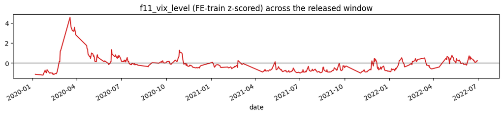

```python
# The realised F11 columns in the feature matrix, and proof of the global broadcast.
f11 = [c for c in matrix.columns if c.startswith("f11_")]
by_suffix = collections.Counter(c.rsplit("_", 1)[1] for c in f11)
print(f"{len(f11)} f11_* columns; by suffix: {dict(by_suffix)}")

d0 = matrix["date"].iloc[len(matrix) // 2]
two = (matrix[(matrix.date == d0) & (matrix.instrument.isin(["cl1s", "es1s"]))]
       .set_index("instrument")[f11[:6]].T)
print(f"Same date ({pd.Timestamp(d0).date()}), two different instruments -> identical macro values:")
display(two.round(3))

vix = matrix[matrix.instrument == "cl1s"].set_index("date")["f11_vix_level"].sort_index()
ax = vix.plot(figsize=(11, 2.6), color="C3")
ax.axhline(0, color="k", lw=0.5)
ax.set_title("f11_vix_level (FE-train z-scored) across the released window")
plt.tight_layout(); plt.show()
```

**How F11 feeds the meta-model.** These 45 standardised, publication-lagged columns join *every* instrument-date row, so the model can learn macro-conditional adjustments to the per-instrument signal (e.g. trust a counter-trend trade less when MOVE and HY-OAS are spiking together).